# Modélisation de la distribution des principales espèces ligneuses dans deux parcs agroforestiers du bassin arachidier sénégalais

HEMA

19 mai 2020

## Netoyage

## Définitions des fonctions

## Importation des données

### Importation des données de terrain

Précisez les noms des différentes espèces à modéliser

Précisez les variables sur la longitude et la latitude

```r
coord<-list()
coord<-c("xcoord","ycoord") #les variables sur la longitude=xcoord et la latitude=ycoord
Base<-Base(Species,coord,espece)
```

### Importations des données raster

#### Importation des Variables sur le Sol(résolution=250m)

Définition de la zone d’étude(il s’agit du parc à Faidherbia albida )

Traitement des données

#### Importation des variables Worlclim(résolution=1km)

Délimiter les variables WorldClim dans la zone d’étude

Raméner les variables worldclim dans la même résolution que celles du Sol

#### Importation des variables topographiques

Réprésentation graphique

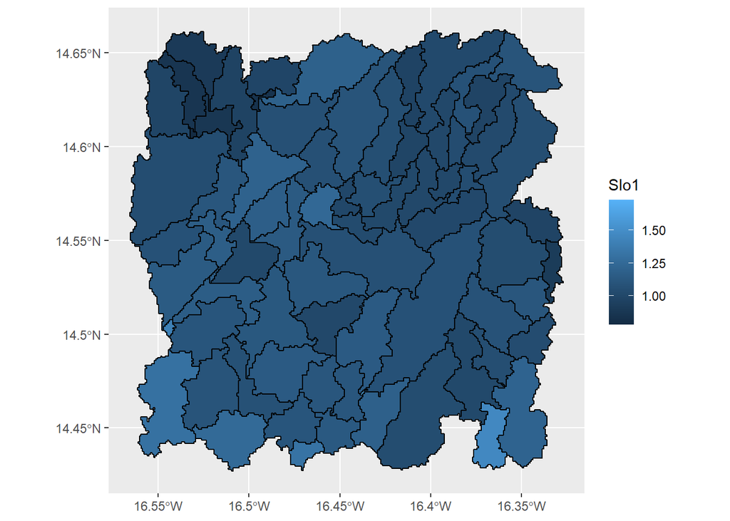

Transformation des variables en raster

### Importation de la variable type de sol dans la zone d’étude

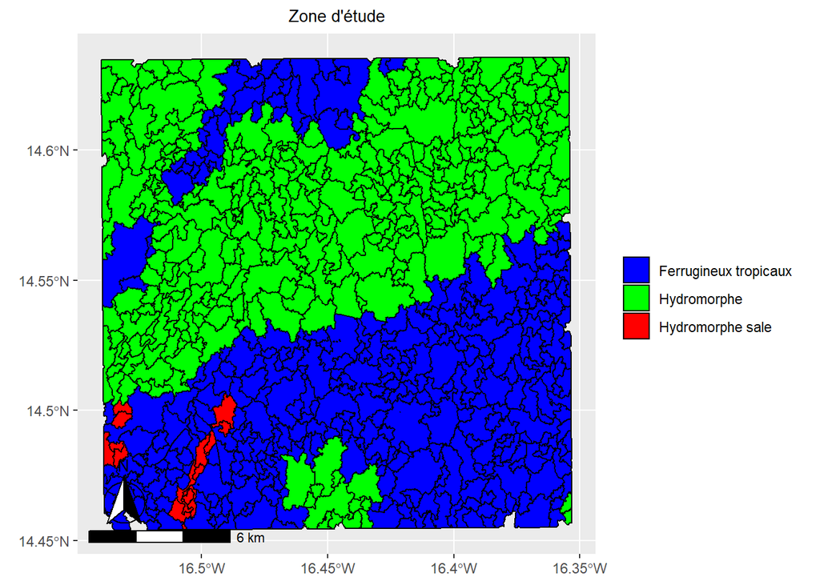

Transformation de la variable type de sol en raster

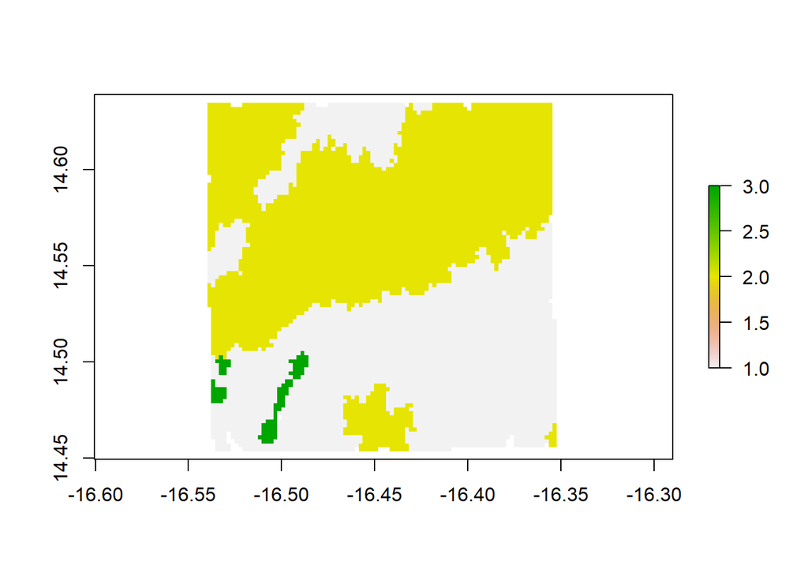

Nous régroupons toutes les variables ensemble

# ENFA

Supprimer les variables bio14,bio19,Sll,Sol(on ne la mets pas dans ENFA car catégorielle). En effet, les variables bio14,bio19 et Sll prennent les mêmes valeurs dans la zone d’étude. Quant à la variable Sol, elle est catégorielle. On ajoute pas ces types de variables pour faire ENFA.

## Constitution des bases de présence des espèces

## Coorélation des prédicteurs

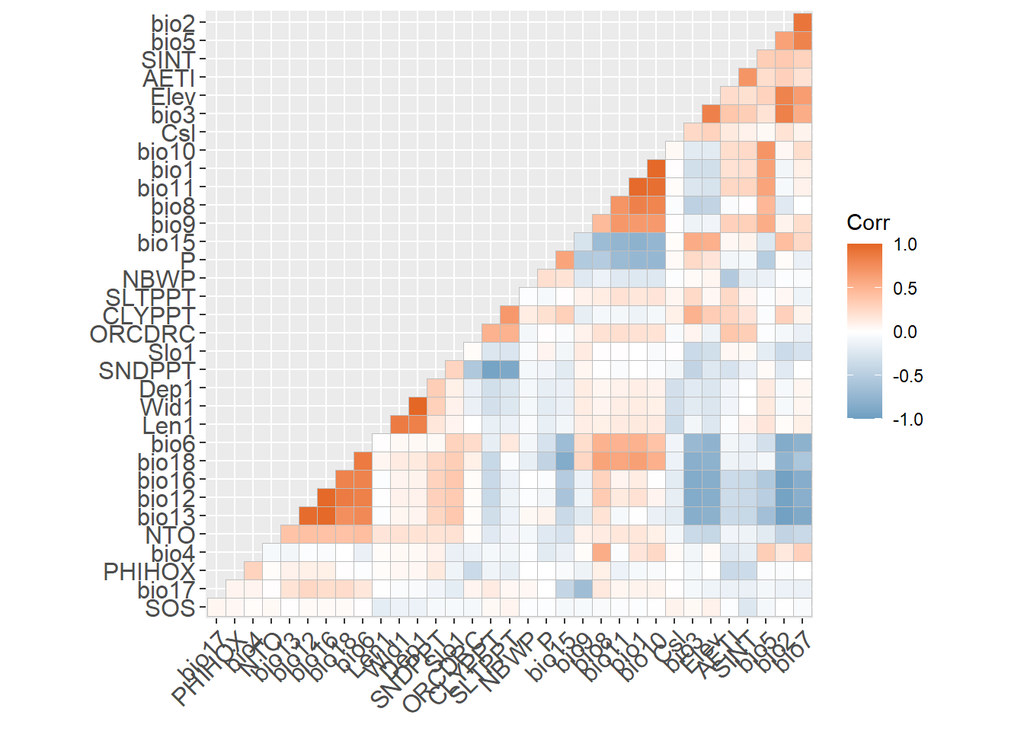

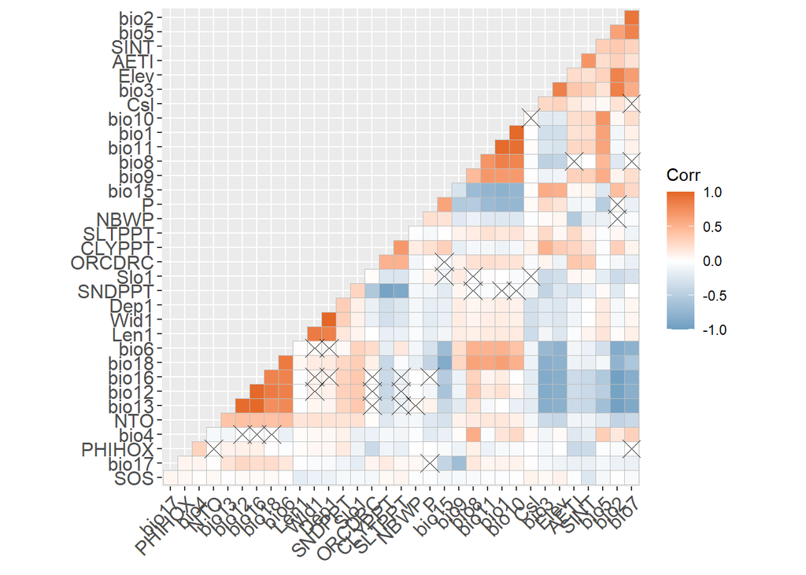

ENFA sur Faidherbia albida

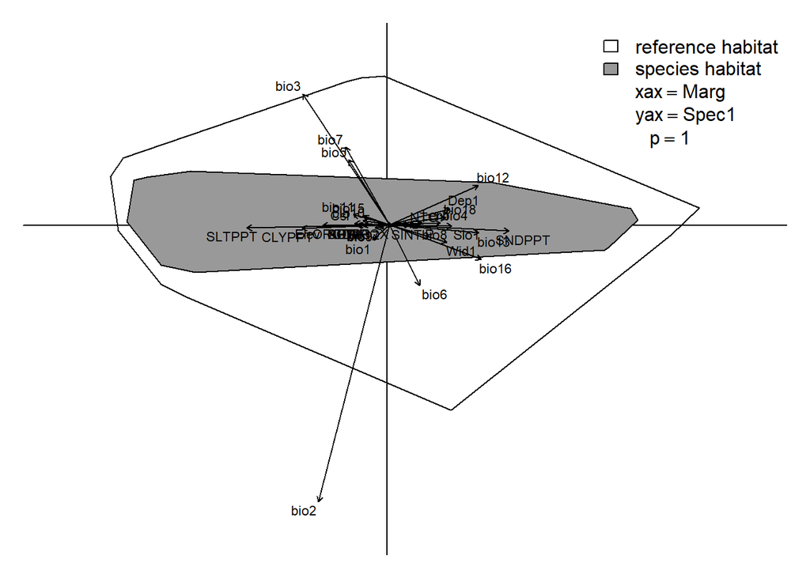

ENFA sur Balanites

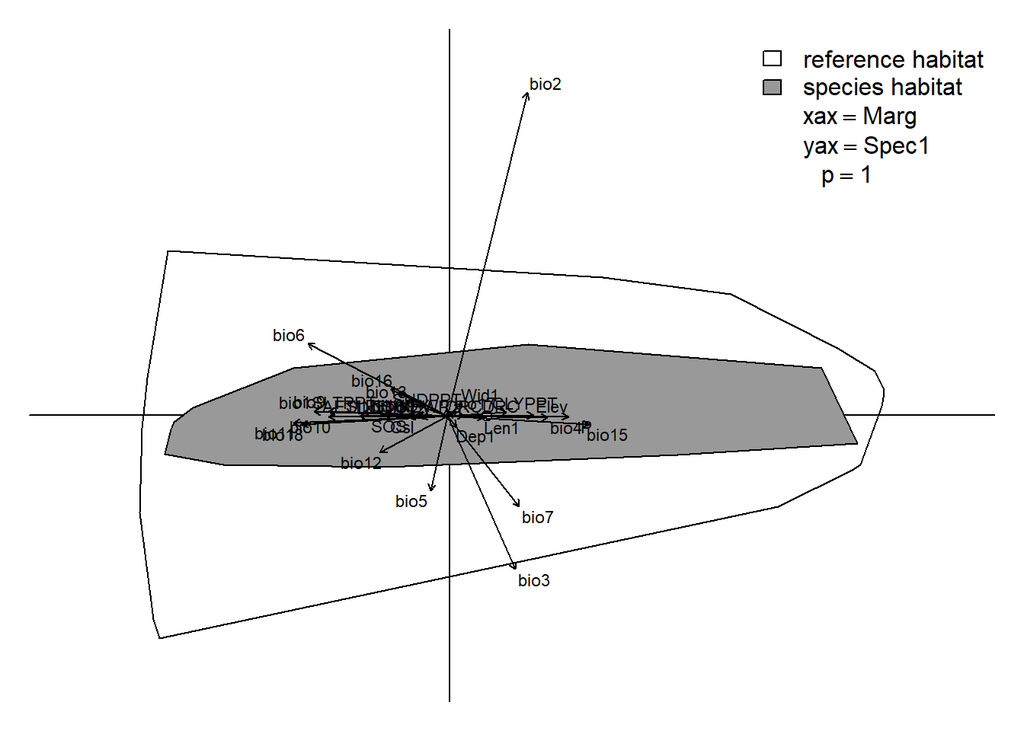

ENFA Anogeissus

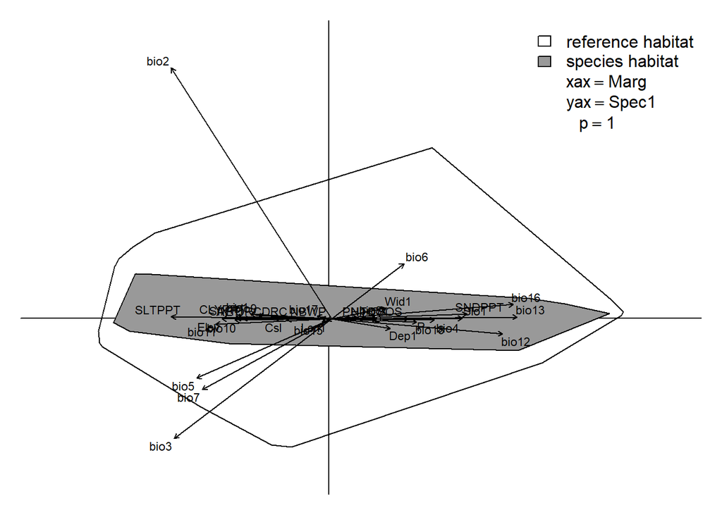

ENFA Adansonia

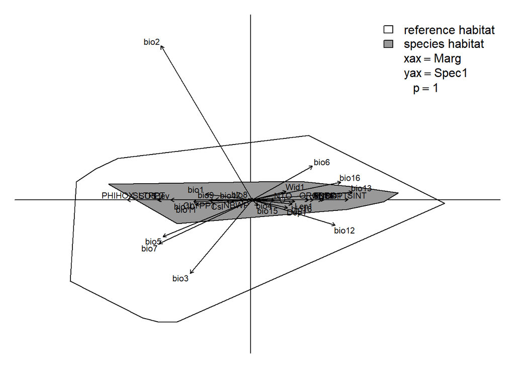

ENFA Acacia

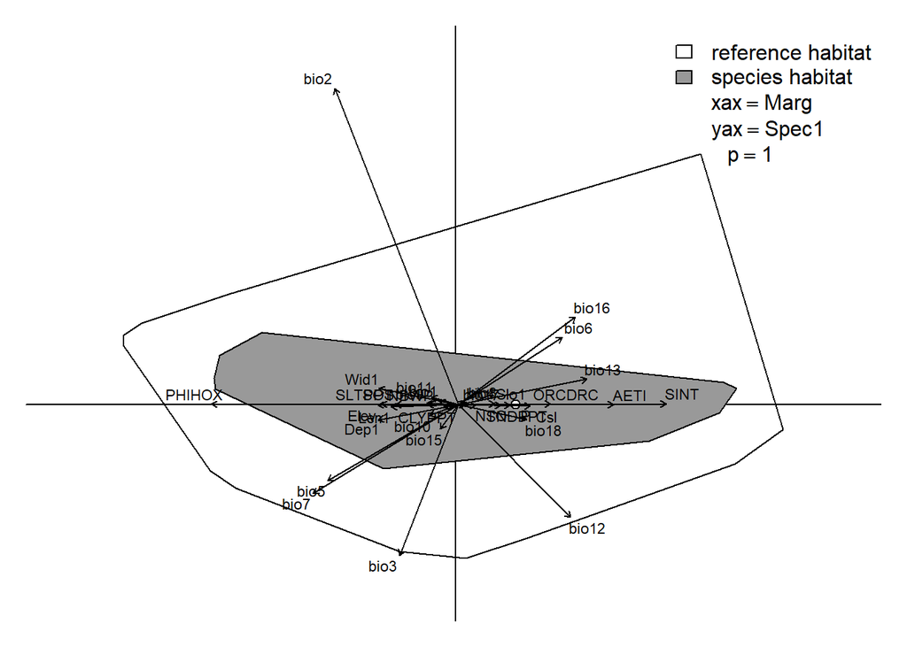

# Variables explicatives des espèces

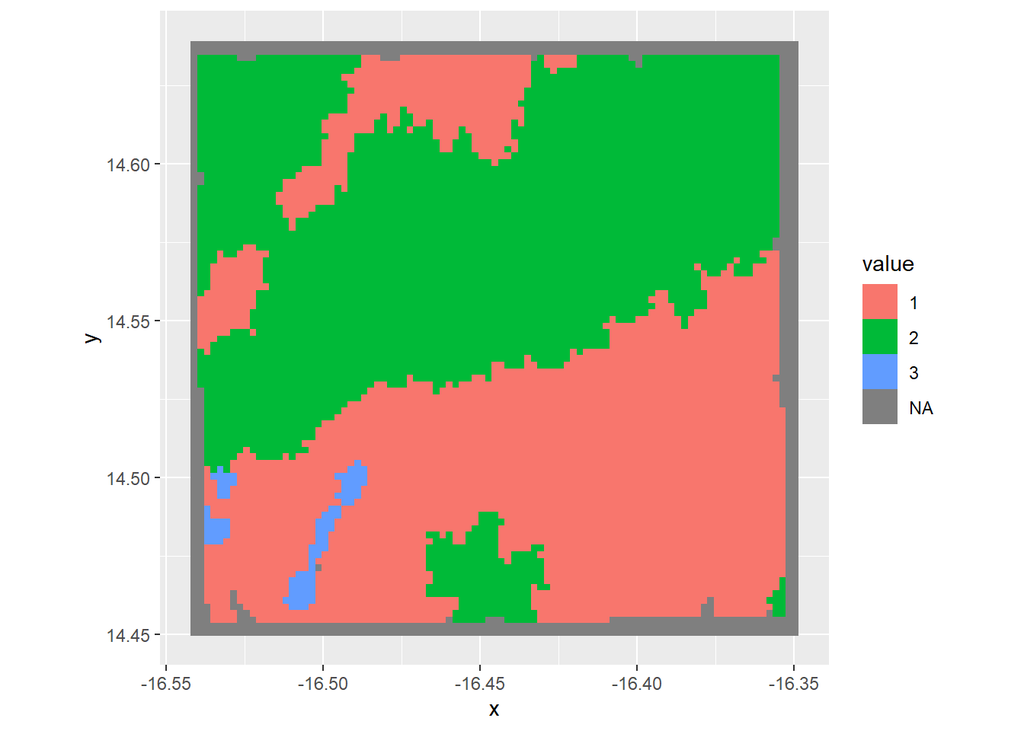

## Variables bioclim

# Constitution des données de test et d’entrainement

# Modélisation des Espèces avec Maxent

## Faidherbia albida

## Balanites aegyptiaca

## Anogeissus

## Adansonia

## Acacia

# Comparaison du modéle avec les deux types de variables

On construit un data frame

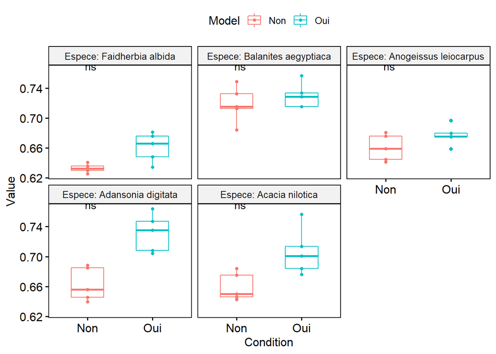